# Homework #2

**See Canvas for this assignment due date**. Complete all of the following problems. Ideally, the theoretical problems should be answered in a Markdown cell directly underneath the question. If you don’t know LaTex/Markdown, you may submit separate handwritten solutions to the theoretical problems. Please do not turn in messy work. Computational problems should be completed in this notebook (using the R kernel is preferred). Computational questions may require code, plots, analysis, interpretation, etc. Working in small groups is allowed, but it is important that you make an effort to master the material and hand in your own work.

## A. Theoretical Problems

### Problem A.1

In class, we analyzed regression with an intercept, $\beta_0$. In some circumstances, we may have theoretical reasons to suggest that the intercept term is zero. As such, some have proposed to not estimate $\beta_0$, and instead, use the one-predictor linear model: $Y_i = \beta_1x_i + \varepsilon_i$. The goal of this problem is to understand some of the consequences of using this model.

**A.1 (a) [8 points] Find the least squares estimator of** $\beta_1$.

Least squares means that we minimize the sum of the squares of the residuals:

$$\begin{align*}
RSS &= \sum^n_{i=1}\left(Y_i - \beta_1x_i\right)^2.
\end{align*}$$

To find the minimum of the $RSS$, we set the derivative equal to zero and solve for $\beta_1$.

$$\begin{align*}
\frac{d RSS}{d\beta_1} &= -2\sum^n_{i=1}\left(Y_i -
\beta_1x_i\right)x_i \overset{set}{=}0\\
&= \sum^n_{i=1}Y_ix_i - \beta_1\sum^n_{i=1}x_i^2\overset{set}{=}0\\
&\implies \widehat\beta_1 =
\frac{\sum^n_{i=1}Y_ix_i}{\sum^n_{i=1}x_i^2}
\end{align*}$$

http://sites.msudenver.edu/ngrevsta/wp-content/uploads/sites/416/2020/02/Notes_07.pdf

**A.1 (b) [4 points] Show that the residuals of this model fit do not necessarily sum to zero.**

You can do this through a simulation if you’d like!

$\sum\widehat\varepsilon_i = n\bar{y} - \left(\frac{\sum x_iy_i}{\sum x_i^2}\right)n\bar{x}$

```r
set.seed(11)
b = 3; n = 15; e = rnorm(n,0,0.5)

x = rnorm(n,0,1); y = b*x + e;
lmod = lm(y ~ x - 1)
summary(lmod)
```

```
##
## Call:
## lm(formula = y ~ x - 1)
##
## Residuals:
##      Min       1Q   Median       3Q      Max
## -0.90629 -0.46483 -0.29757 -0.01558  0.69857
##
## Coefficients:
##   Estimate Std. Error t value Pr(>|t|)
## x   3.1667     0.2488   12.73 4.38e-09 ***
## ---
## Signif. codes:  0 '***' 0.001 '**' 0.01 '*' 0.05 '.' 0.1 ' ' 1
##
## Residual standard error: 0.5006 on 14 degrees of freedom
## Multiple R-squared:  0.9205, Adjusted R-squared:  0.9148
## F-statistic:   162 on 1 and 14 DF,  p-value: 4.376e-09
```

```r
#sum(x*y)/sum(x^2)

r = resid(lmod)
sr = sum(resid(lmod))
#n*mean(y) - sum(x*y)/sum(x^2)*n*mean(x)
```

**A.1 (c) [6 points] Show that**

$$\begin{align*}
\sum^n_{i=1}(Y_i - \widehat{Y}_i)(\widehat{Y}_i - \bar{Y})
\end{align*}$$

**is not necessarily zero. Use this fact to argue that, for this model, the coefficient of determination,** $R^2$ does *not* have the interpretation given in class.

Again, this proof can be done through simulation.

See the simulation below:

```r
f = fitted(lmod)
sum((y-f)*(f-mean(y)))
```

```
## [1] -2.377535
```

```r
#sum(r*f)
#mean(y)*sum(r)
```

-2.37753492752217

### Problem A.2

Suppose that, for $i = 1,...,n$, the pairs $(x_i, y_i)$ are generated according to a simple linear regression model

$$Y_i = \beta_0 + \beta_1x_i +
\varepsilon_i,$$

where $x_i$ are fixed constants and $\varepsilon_i \overset{iid}{\sim} N(0,\sigma^2)$. Then, imagine reparameterizing the model as

$$Y_i = \beta^*_0 +
\beta^*_1\left(\frac{x_i- \bar{x}}{sd(x)}\right) +
\varepsilon_i,$$

where $sd(x) = \frac{1}{n-1}\sum(x_i - \bar{x})^2$.

Let $\widehat\beta_j$ be the least squares estimator of $\beta_j$, and $\widehat\beta^*_j$ be the least squares estimator of $\beta^*_j$ for $j=0,1$.

**A.2 (a) [7 points] Show that** $\widehat\beta^*_1 \ne \widehat\beta_1$.

HINT: For regression with one predictor, $\displaystyle \widehat\beta_1 = \frac{\sum^n_{i=1}\left( x_i - \bar{x}\right)\left(y_i - \bar{y} \right)}{\sum^n_{i=1}\left(x_i - \bar{x}\right)^2}$.

Let $z_i = (x_i - \bar{x} )\big/sd(x)$. Note that $\bar{z} = \frac{1}{n}\sum z_i = 0$. Thus,

$$\begin{align*}
\widehat\beta^*_1 &= \frac{\sum^n_{i=1}\left( z_i -
\bar{z}\right)\left(y_i - \bar{y} \right)}{\sum^n_{i=1}\left(z_i -
\bar{z}\right)^2} = \frac{\sum^n_{i=1}\left( z_i \right)\left(y_i -
\bar{y} \right)}{\sum^n_{i=1}\left(z_i\right)^2} \\
&= \frac{\sum^n_{i=1}\left(\frac{ x_i -
\bar{x}}{sd(x)}\right)\left(y_i - \bar{y}
\right)}{\sum^n_{i=1}\left(\frac{x_i - \bar{x}}{sd(x)}\right)^2} =
\frac{\frac{1}{sd(x)}\sum^n_{i=1}\left(x_i - \bar{x}\right)\left(y_i -
\bar{y} \right)}{\frac{1}{sd(x)^2}\sum^n_{i=1}\left(x_i -
\bar{x}\right)^2} \\
&= \sqrt{\frac{1}{n-1}\sum(x_i - \bar{x})^2}
\frac{\sum^n_{i=1}\left(x_i - \bar{x}\right)\left(y_i - \bar{y}
\right)}{\sum^n_{i=1}\left(x_i - \bar{x}\right)^2} \\
&= \frac{\sum^n_{i=1}\left(x_i - \bar{x}\right)\left(y_i - \bar{y}
\right)}{ \sqrt{\frac{1}{n-1}\sum(x_i - \bar{x})^2} } \\
&\ne \widehat\beta_1.
\end{align*}$$

We can also show/verify this by simulation. Note that the least squares estimate associated with $x$ is not the same as the one associated with $z$.

```r
z = (x-mean(x))/sd(x);

#original regression
lmod_x = lm(y ~ x)
summary(lmod_x)
```

```
##
## Call:
## lm(formula = y ~ x)
##
## Residuals:
##      Min       1Q   Median       3Q      Max
## -0.56509 -0.32868 -0.07698  0.21473  0.87981
##
## Coefficients:
##             Estimate Std. Error t value Pr(>|t|)
## (Intercept)  -0.2183     0.1366  -1.598    0.134
## x             2.9814     0.2630  11.335 4.13e-08 ***
## ---
## Signif. codes:  0 '***' 0.001 '**' 0.01 '*' 0.05 '.' 0.1 ' ' 1
##
## Residual standard error: 0.4749 on 13 degrees of freedom
## Multiple R-squared:  0.9081, Adjusted R-squared:  0.9011
## F-statistic: 128.5 on 1 and 13 DF,  p-value: 4.126e-08
```

```r
#standardized regression
lmod_z = lm(y ~ z);
summary(lmod_z)
```

```
##
## Call:
## lm(formula = y ~ z)
##
## Residuals:
##      Min       1Q   Median       3Q      Max
## -0.56509 -0.32868 -0.07698  0.21473  0.87981
##
## Coefficients:
##             Estimate Std. Error t value Pr(>|t|)
## (Intercept)  -0.9014     0.1226  -7.351 5.58e-06 ***
## z             1.4388     0.1269  11.335 4.13e-08 ***
## ---
## Signif. codes:  0 '***' 0.001 '**' 0.01 '*' 0.05 '.' 0.1 ' ' 1
##
## Residual standard error: 0.4749 on 13 degrees of freedom
## Multiple R-squared:  0.9081, Adjusted R-squared:  0.9011
## F-statistic: 128.5 on 1 and 13 DF,  p-value: 4.126e-08
```

```r
#beta_hat_star = 1/sqrt(n-1)*sum((x-mean(x))*(y-mean(y)))/(sqrt(sum((x-mean(x))^2)))
```

**A.2 (b) [4 points] Show that, in general,** $\widehat\beta^*_0 \ne \widehat\beta_0$, and find $\widehat\beta^*_0$ in terms of $Y_i$. In what particular case is $\widehat\beta^*_0 = \widehat\beta_0$?

HINT: For SLR, $\widehat\beta_0 = \bar{y} - \widehat\beta_1 \bar{x}$.

Again, note that $\bar{z} = 0$. Thus, $\widehat\beta^*_0 = \bar{y} - \widehat\beta_1 \bar{z} = \bar{y} \ne \widehat\beta_0$ unless $\bar{x} = 0$.

**A.2 (c) [5 points] Why might the reparameterized model be beneficial?**

This reparameterized model is beneficial because it helps with the interpretation of the parameters. Once centered, the interpretation of $\widehat\beta^*_0$ becomes the average value of $y$ when $x$ is equal to its (sample) mean. This is better than $x = 0$ in a lot of cases because often $x=0$ is not possible (e.g., if $x$ is height, weight).

The interpretation of $\widehat\beta^*_1$ is also better in some sense. A one-unit increase in a predictor might not be all that meaningful. For example, suppose that $x = $ *yearly salary* and is measured in dollars. Knowing how the response changes on average with respect to a one-dollar increase in $x$ may be too small to be all that meaningful. A one-unit increase in $z$ is equivalent to a *one-standard deviation* increase in $z$.

### Problem A.3: The multivariate normal distribution and its application to regression

The multivariate normal distribution of an $n$-dimensional vector $\mathbf{Y} = (Y_1,...,Y_n)^T$ can be written in the following notation:

$$\mathbf{Y} \sim N\left(\boldsymbol{\mu},
\Sigma \right),$$

where $\boldsymbol{\mu} = (\underbrace{ \mu_1 }_{E(Y_1)},...,\underbrace{ \mu_n }_{E(Y_n)})^T$ is a vector of means and

$\Sigma = \left(\begin{matrix} \sigma_{Y_1, Y_1} & \sigma_{Y_1, Y_2} & \cdots & \sigma_{Y_1, Y_n} \\ \sigma_{Y_2, Y_1} & \sigma_{Y_2, Y_2} & \cdots & \sigma_{Y_2, Y_n} \\ \vdots & \vdots & \ddots & \vdots \\ \sigma_{Y_n, Y_1} & \sigma_{Y_n, Y_2} & \cdots & \sigma_{Y_n, Y_n} \\ \end{matrix}\right)$

and $\Sigma$ is a *variance-covariance* matrix with entries $\displaystyle \sigma_{Y_i, Y_j} = Cov(Y_i,Y_j)$ for $i,j = 1,...,n$.

What does it mean for a vector to have a *multivariate normal distribution*? It means that, for any constant (i.e., *non-random*) vector $\mathbf{a} = (a_1,a_2,...,a_n)^T$, every linear combination $X = \mathbf{a}^T\mathbf{Y} = a_1Y_1 + a_2Y_2 + ... + a_nY_n$ has a univariate normal distribution with mean $\mu_X = \mathbf{a}^T\boldsymbol{\mu}$ and variance $\sigma_X^2 = \mathbf{a}^T\Sigma\mathbf{a}$.

Further, note that: if $\mathbf{b}$ is an $m\times1$ constant vector, and $B$ is an $m \times n$ constant matrix, then $\mathbf{b} + B\mathbf{Y} \sim N\left(\mathbf{b} + B\boldsymbol\mu, B\Sigma B^T \right)$.

Ok, those were some great properties, and you should make use of them below.

Consider the linear regression model $\mathbf{Y} = X\boldsymbol\beta + \boldsymbol{\varepsilon}$, where $\,\boldsymbol{\varepsilon} {\sim} N(\mathbf{0},\sigma^2I_n)$, $\mathbf{0}$ is an $n\times 1$ vector, and $I_n$ is the $n \times n$ identity matrix.

**A.2 (a) [5 points] Find the distribution of** $\varepsilon_i$.

Use the properties above!

Let $\mathbf{a} = (0,0,...,0,1,0,...0)^T$ be of length $n$, where $1$ is in the $i^{th}$ position. Then $\varepsilon_i = \mathbf{a}^T\boldsymbol{\varepsilon}$ is normally distributed, by definition of the multivariate normal distribution. Further, from above:

- $\mu_{\varepsilon_i} = \mathbf{a}^T\mathbf{0} = 0$.
- $\sigma^2_{\varepsilon_i} = \mathbf{a}^T\sigma^2I_n \mathbf{a} = \sigma^2\mathbf{a}^TI_n \mathbf{a} = \sigma^2$.

**A.2 (b) [5 points] Show that** $\mathbf{Y} \sim N(X\boldsymbol\beta, \sigma^2I_n)$

This follows directly from above, with $\mathbf{b} = X\boldsymbol\beta$, $B = I_n$

**A.2 (c) [10 points] Let** $\widehat{\boldsymbol\beta}$ be the least squares estimator of $\boldsymbol{\beta}$. Prove that $\boldsymbol{\widehat\beta}$ has a multivariate normal distribution. What are the mean and variance-covariance matrix?

Let $\mathbf{a} = \mathbf{0}$ and $B = \left(X^TX\right)^{-1}X^T$. Then it follows from above that $\boldsymbol{\widehat\beta} = \mathbf{a} + B\mathbf{Y} = B\mathbf{Y} \sim N\left(\underbrace{BX\boldsymbol\beta}_{E(\boldsymbol{\widehat\beta})},\, \underbrace{ B\sigma^2I_n B^T}_{Cov(\widehat\beta_i, \widehat\beta_j)}\right)$. Note that

- $E(\boldsymbol{\widehat\beta}) = E(B\mathbf{Y}) = BE\left(\mathbf{Y}\right) = \left(X^TX\right)^{-1}X^T E(\mathbf{Y}) = \left(X^TX\right)^{-1}X^T X\boldsymbol\beta = \boldsymbol\beta$
- $Cov(\widehat\beta_i, \widehat\beta_j) = B\sigma^2I_n B^T = \sigma^2 \left(X^TX\right)^{-1}X^T I_n X\left(X^TX\right)^{-1} = \sigma^2 \left(X^TX\right)^{-1}X^T X\left(X^TX\right)^{-1} = \sigma^2 \left(X^TX\right)^{-1}$

## B. Computational Problems

### Problem B.1

**B.1 (a) [10 points] Run a simulation to confirm your result in problem A.2 (a) - (b). Let’s do this in parts. In the cell directly below:**

- Set `n = 50`, $= $ `beta = c(1, 3.5)`.
- Simulate $n$ predictor values ($x$) randomly from $N(3,1)$. Store those values in a variable `x`.
- Simulate $n$ random error terms from $N(0,2)$. Store them in the variable `e`.
- Calculate the response ($y$) according to `y = b0 + b1 x + e`
- Fit a simple linear regression model to the data using the `lm()` function. Store the `lm()` object in a variable `l` and the coefficients of that model in a variable `b1 = coef(l)`.

```r
set.seed(1918)
n = 50; beta = c(1,3.5);

### BEGIN SOLUTION HERE
e = rnorm(n, 0, 2)
x = rnorm(n,3,1)
y = beta[1] + beta[2]*x + e
l = lm(y ~ x)
### END SOLUTION HERE
b1 = coef(l); b1
```

```
## (Intercept)           x
##   0.4856487   3.5849160
```

**B.1 (b) [8 points] Now:**

- **Center and scale the predictor values (as done in A.2 above) and store those values in a variable `z`.**
- **Fit a simple linear regression model to the new data,** $(z_i, y_i)$, using the `lm()` function. Store the `lm()` object in a variable `l2` and the coefficients of that model in a variable `b2 = coef(l2)` (`b2` should be a vector of length $2$).
- **In the Markdown cell below the hidden test cell, describe the differences between `b` and `b2`.**

```r
### BEGIN SOLUTION HERE
z = (x - mean(x))/sd(x)
l2 = lm(y ~ z)
### END SOLUTION HERE
b2 = coef(l2); b2
```

```
## (Intercept)           z
##   11.697941    4.133579
```

We see a confirmation of A.3 (a) - (b), that is, the slope terms and the intercept terms are different.

### B.2 The “gala” dataset, revisited.

**B.2 (a) [0 points] Load the “gala” dataset, and perform a linear regression with Species as the response and Endemics, Elevation, Nearest, and Adjacent as predictors. Store your `lm()` object in the variable `lm_species`. Note that you already did this on the first assignment.**

```r
gala = read.csv("https://raw.githubusercontent.com/CUBuffs/Statistical-Learning-/main/Modern%20Regression%20Analysis/Datasets/gala.csv")
gala = gala[,-1]
summary(gala)
```

```
##     Species          Endemics          Area            Elevation
##  Min.   :  2.00   Min.   : 0.00   Min.   :   0.010   Min.   :  25.00
##  1st Qu.: 13.00   1st Qu.: 7.25   1st Qu.:   0.258   1st Qu.:  97.75
##  Median : 42.00   Median :18.00   Median :   2.590   Median : 192.00
##  Mean   : 85.23   Mean   :26.10   Mean   : 261.709   Mean   : 368.03
##  3rd Qu.: 96.00   3rd Qu.:32.25   3rd Qu.:  59.237   3rd Qu.: 435.25
##  Max.   :444.00   Max.   :95.00   Max.   :4669.320   Max.   :1707.00
##     Nearest          Scruz           Adjacent
##  Min.   : 0.20   Min.   :  0.00   Min.   :   0.03
##  1st Qu.: 0.80   1st Qu.: 11.03   1st Qu.:   0.52
##  Median : 3.05   Median : 46.65   Median :   2.59
##  Mean   :10.06   Mean   : 56.98   Mean   : 261.10
##  3rd Qu.:10.03   3rd Qu.: 81.08   3rd Qu.:  59.24
##  Max.   :47.40   Max.   :290.20   Max.   :4669.32
```

```r
lm_species = lm(Species ~ Endemics + Elevation + Nearest + Adjacent, data = gala)
summary(lm_species)
```

```
##
## Call:
## lm(formula = Species ~ Endemics + Elevation + Nearest + Adjacent,
##     data = gala)
##
## Residuals:
##     Min      1Q  Median      3Q     Max
## -77.232 -10.318   3.412   9.521  70.768
##
## Coefficients:
##               Estimate Std. Error t value Pr(>|t|)
## (Intercept) -17.510039   8.333335  -2.101   0.0459 *
## Endemics      4.192551   0.429056   9.772  5.1e-10 ***
## Elevation    -0.008594   0.032903  -0.261   0.7961
## Nearest      -0.203743   0.376472  -0.541   0.5932
## Adjacent     -0.005629   0.009876  -0.570   0.5738
## ---
## Signif. codes:  0 '***' 0.001 '**' 0.01 '*' 0.05 '.' 0.1 ' ' 1
##
## Residual standard error: 28.59 on 25 degrees of freedom
## Multiple R-squared:  0.9464, Adjusted R-squared:  0.9378
## F-statistic: 110.3 on 4 and 25 DF,  p-value: 1.673e-15
```

**B.2 (b) [10 points] Calculate the residual sum of squares, and the total sum of squares for this model, and store these quantities in `rss` and `tss`, respectively. Then, use these calculations to verify the Multiple R-squared calculation in the summary from the previous part. Store your** $R^2$ for this model in `r2`. Interpret $R^2$ (assume, for the moment, that the model is correct, and so the interpretation holds). Note that the anova table calculates sums of squares. Why doesn’t the total sum of squares show up in the table?

```r
### BEGIN SOLUTION HERE
rss = sum(resid(lm_species)^2)
tss = with(gala, sum((Species - mean(Species))^2))
r2 = 1-rss/tss
cat("The TSS is ", tss, ".")
```

```
## The TSS is  381081.4 .
```

```r
cat("The RSS is ", rss, ".")
```

```
## The RSS is  20428.8 .
```

```r
cat("The r2 is ", r2, ".")
```

```
## The r2 is  0.9463925 .
```

```r
### END SOLUTION HERE
anova(lm_species)
```

```
## Analysis of Variance Table
##
## Response: Species
##           Df Sum Sq Mean Sq  F value Pr(>F)
## Endemics   1 359208  359208 439.5849 <2e-16 ***
## Elevation  1   1007    1007   1.2325 0.2775
## Nearest    1    172     172   0.2107 0.6502
## Adjacent   1    265     265   0.3249 0.5738
## Residuals 25  20429     817
## ---
## Signif. codes:  0 '***' 0.001 '**' 0.01 '*' 0.05 '.' 0.1 ' ' 1
```

The TSS is 381081.4 .The RSS is 20428.8 .The r2 is 0.9463925 .

Assuming that the model is correct, approximately $95\%$ of the variability in `species` can be explained by `Endemics`, `Elevation`, `Nearest`, and `Adjacent`.

Note that the total sum of squares is not in the table because it can easily be calculated from quantities that are: $TSS = RSS + ESS$.

**B.2 (c) [4 points] Plot the residuals vs the fitted values. Based on what we’ve discussed in class, what do you expect to see in this plot? Do you see what you expect to see? If not, what does that mean?**

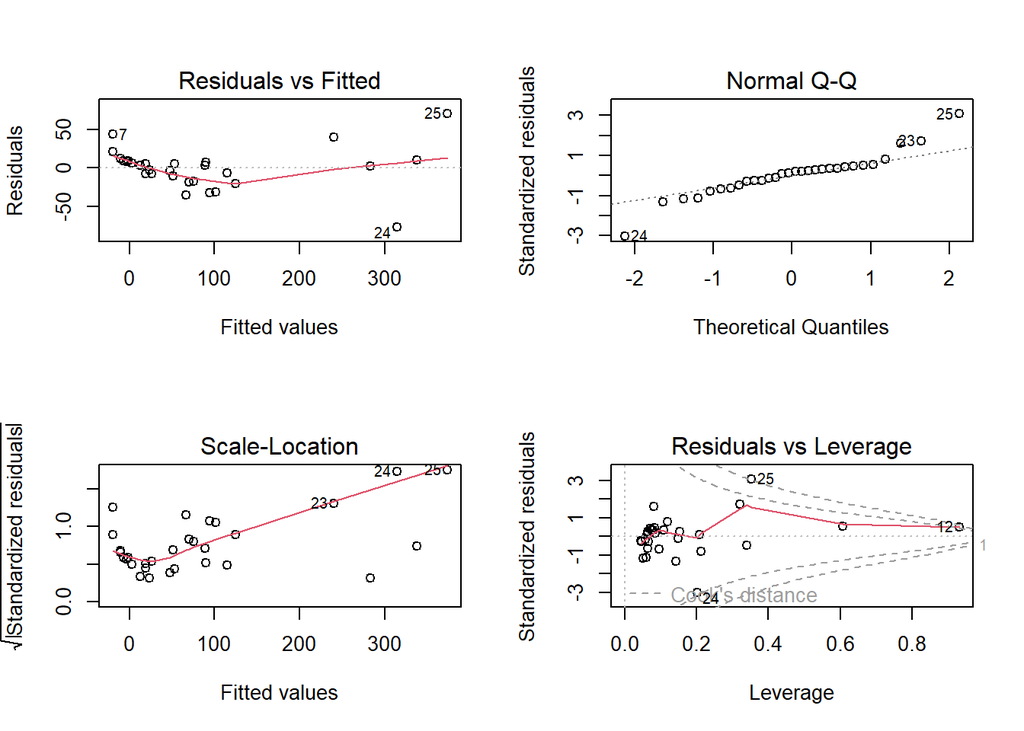

```r
par(mfrow = c(2,2))
plot(lm_species)
```

We would expect to see no correlation between the residuals and the fitted values (the first plot above). But there does seem to be a downward linear trend, for small fitted values (and other issues that we’ll discuss in unit #4).

### B.3

Consider the data below on the number of hours of exercise per week versus the risk of developing a disease. We might look at two sets of patients, those below the age of 50 and those over the age of 50.

**B.3 (a) [4 points] Estimate the regression line**
$$p_i = \beta_0 + \beta_1 hours_i +
\varepsilon_i,$$
where $\varepsilon_i$ is assumed to be $N(0,\sigma^2)$. Denote the estimated regression line as
$$\widehat p_i =
\widehat\beta_0 + \widehat\beta_1 hours_i.$$
Plot the estimated regression line on top of the data.

```r
library(ggplot2)
df = read.csv("https://raw.githubusercontent.com/CUBuffs/Statistical-Learning-/main/Modern%20Regression%20Analysis/Datasets/colorado.edu_attached-files_simp.txt", header = TRUE, sep = "\t")

df$p = df$p/100
head(df)
```

```
##   ages     hours         p
## 1   50 3.6239201 0.2952386
## 2   26 2.4600381 0.2210206
## 3   35 3.8070524 0.2095405
## 4   28 3.0390379 0.1829365
## 5   43 0.7089589 0.3309662
## 6   45 4.4194311 0.2976093
```

```r
lmod_total = lm(p ~ hours, data = df)
#plot(df$hours, df$p, xlab = "hours", ylab = "p")
#abline(lmod_total$coef)
summary(lmod_total)
```

```
##
## Call:
## lm(formula = p ~ hours, data = df)
##
## Residuals:
##       Min        1Q    Median        3Q       Max
## -0.279701 -0.085412 -0.008813  0.076613  0.266713
##
## Coefficients:
##             Estimate Std. Error t value Pr(>|t|)
## (Intercept) 0.277558   0.018034  15.391  < 2e-16 ***
## hours       0.013972   0.003796   3.681 0.000299 ***
## ---
## Signif. codes:  0 '***' 0.001 '**' 0.01 '*' 0.05 '.' 0.1 ' ' 1
##
## Residual standard error: 0.114 on 198 degrees of freedom
## Multiple R-squared:  0.06405,    Adjusted R-squared:  0.05933
## F-statistic: 13.55 on 1 and 198 DF,  p-value: 0.0002994
```

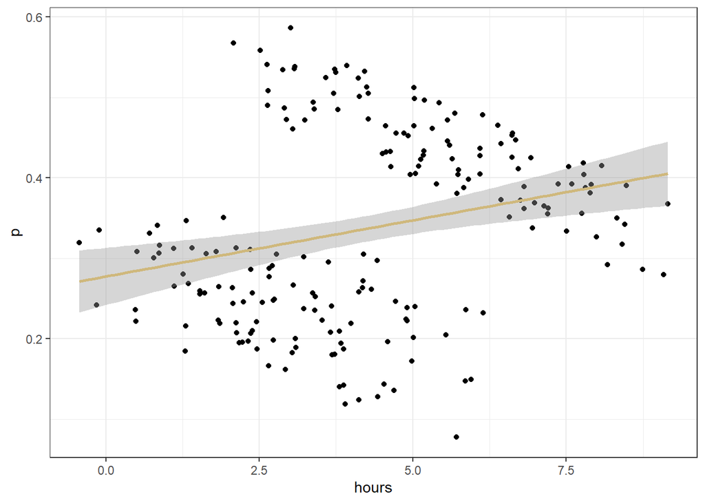

```r
options(repr.plot.width = 6, repr.plot.height = 6)
ggplot(df, aes(x = hours, y = p)) + geom_point() +
geom_smooth(method = lm, col = "#CFB87C") +
theme_bw()
```

**B.3 (b) [3 points] What is the interpretation of** $\widehat\beta_1$?

Every additional hour of exercise is associated with a mean increase in risk of $\approx 0.014$. So, more exercise, more risk of developing the disease? Does exercise *cause* the disease?

**B.3 (c) [9 points] Now, create a variable that is 1 if the individual is over 50 years old and 0 otherwise. Plot** $p$ against $hours$ for each subgroup. What do you notice?

```r
x = ifelse(df$age > 50, 1,0)
#df = cbind(df,x)
dfu = df[x == 0,]
dfo = df[x == 1,]

df$fifty = as.factor(ifelse(df$age > 50, 1,0))
```

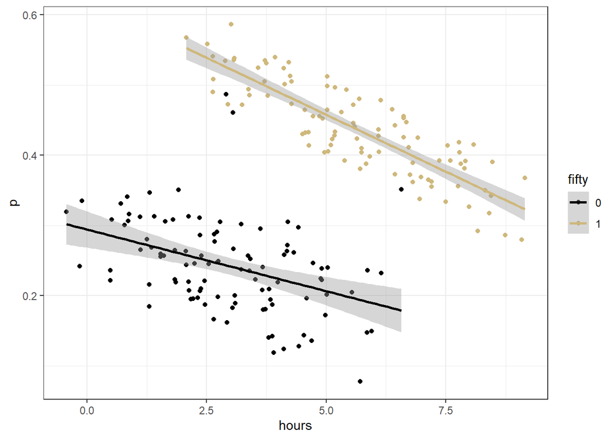

```r
#par(mfrow = c(1,2))
#ggplot(dfu, aes(x = hours, y = p)) + geom_point()
#ggplot(dfo, aes(x = hours, y = p)) + geom_point()

ggplot(df,aes(x = hours, y = p, color = fifty)) +
    geom_point() +
    geom_smooth(method = "lm") +
    scale_color_manual(values = c("black", "#CFB87C")) +
    theme_bw()
```

There seem to be two distinct groups, and each shows a downward trend.

**B.3 (d) [9 points] Estimate two regression lines: one for only the individuals under 50, and the other for individuals over 50. Interpret the slope coefficients of each.**

```r
lmodu = lm(p~hours, data = dfu)
lmodo = lm(p~hours, data = dfo)

summary(lmodo)
```

```
##
## Call:
## lm(formula = p ~ hours, data = dfo)
##
## Residuals:
##      Min       1Q   Median       3Q      Max
## -0.06263 -0.03002  0.00195  0.03044  0.06417
##
## Coefficients:
##              Estimate Std. Error t value Pr(>|t|)
## (Intercept)  0.619998   0.012086   51.30   <2e-16 ***
## hours       -0.032428   0.002044  -15.87   <2e-16 ***
## ---
## Signif. codes:  0 '***' 0.001 '**' 0.01 '*' 0.05 '.' 0.1 ' ' 1
##
## Residual standard error: 0.03507 on 95 degrees of freedom
## Multiple R-squared:  0.726,  Adjusted R-squared:  0.7232
## F-statistic: 251.8 on 1 and 95 DF,  p-value: < 2.2e-16
```

```r
summary(lmodu)
```

```
##
## Call:
## lm(formula = p ~ hours, data = dfu)
##
## Residuals:
##       Min        1Q    Median        3Q       Max
## -0.116548 -0.045052 -0.000001  0.037414  0.243181
##
## Coefficients:
##              Estimate Std. Error t value Pr(>|t|)
## (Intercept)  0.294337   0.013039  22.574  < 2e-16 ***
## hours       -0.017539   0.003949  -4.441  2.3e-05 ***
## ---
## Signif. codes:  0 '***' 0.001 '**' 0.01 '*' 0.05 '.' 0.1 ' ' 1
##
## Residual standard error: 0.06098 on 101 degrees of freedom
## Multiple R-squared:  0.1634, Adjusted R-squared:  0.1551
## F-statistic: 19.72 on 1 and 101 DF,  p-value: 2.296e-05
```

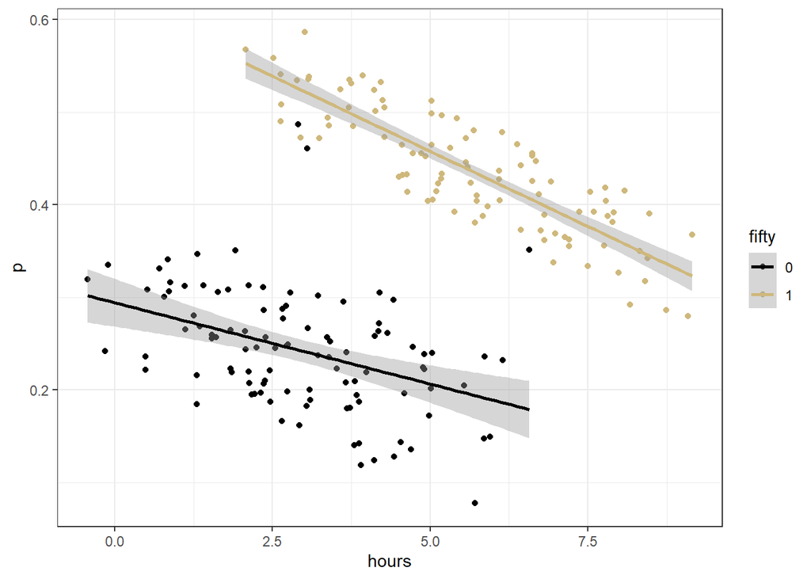

```r
ggplot(df,aes(x = hours, y = p, color = fifty)) +
    geom_point() +
    geom_smooth(method = "lm") +
    scale_color_manual(values = c("black", "#CFB87C")) +
    theme_bw()
```

For individuals over 50 years old, every additional hour of exercise is associated with a mean decrease in risk of $\approx 0.032$. So, for these individuals: more exercise is associated with a lower risk of developing the disease?

For individuals under 50 years old, every additional hour of exercise is associated with a mean decrease in risk of $\approx 0.018$. So, for these individuals: more exercise is associated with a lower risk of developing the disease?

**B.3 (e) [3 points] Compare your coefficient interpretations in B.3 (d) and B.3 (b). What do you notice? Is it true that the more you exercise, the lower your probability of the disease?**

Without conditioning on age, we saw that exercise was associated with an increased risk. After conditioning on age, we saw that exercise is associated with a decreased risk. It is not clear which regression interpretation is correct.

**B.3 (f) [3 points] Plot the residuals** $\varepsilon_i = p_i - \widehat p_i$ against the fitted values, $\widehat p_i$ for each model. What do you notice?

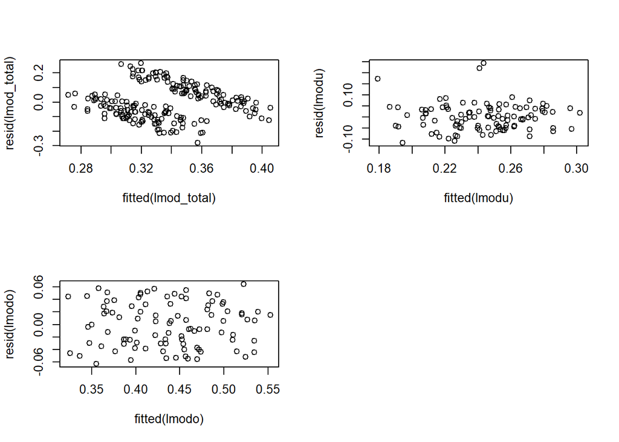

```r
par(mfrow = c(2,2))
plot(fitted(lmod_total), resid(lmod_total))
plot(fitted(lmodu), resid(lmodu))
plot(fitted(lmodo), resid(lmodo))
```

**B.3 (g) [3 points] Which model would you prefer and why?**

Given the visualizations of the regression lines superimposed on the data, and the plot of the residuals vs fitted values, it appears that the regression that includes age is the better model.

Note: some argue that what we really need in a dataset like this is a *causal diagram*. A causal diagram is a set of nodes and arrows that show the hypothesized causal relationships between variables. Plausibly, age is causally related to the number of hours of exercise per week. Also, age is causally related to risk. And the number of hours of exercise per week is causally related to risk.